# Analysis of Movies

CMSC320 Final Project

By: Sumit Nawathe, Eric Zhu

[figure not shown]

Image source: https://www.dish.com/dig/april-movie-rentals-on-dish/

1. Introduction
2. Data Collection and Preprocessing
   - Raw Movielens
   - Kaggle Movielens Companion
   - Combining Datasets
   - Preprocessing and Encoding
3. Data Exploration
   - Importance of Budget
   - Differences By Genre and Company
   - Distribution of Timing
   - Miscellaneous
4. Modeling
   - Random Forest
   - K-Nearest Neighbors
   - Neural Network
5. Upcoming Movie Predictions
6. Conclusion

## Section 1: Introduction

It goes without saying that movies have been a pivotal part of pop culture over the past half-century and have been influential in shaping our generation. Franchises such as Marvel, Harry Potter, and Star Wars have become household names that almost all Americans know of. Yet, not every movie attains this level of success: while some niche films remain cult classics, sometimes even large and ambitious projects can fall into obscurity.

Our goal is to analyze whether a movie's success can be predicted, and if so, what aspects contribute to a movie's success? We will define success as a movie's box office gross revenue, since this is a easily quantifiable metric and is a strong indicator of popularity and demand.

To do this, we will collect a dataset of movie characteristics and examine it to find what factors are most influential. Then, we will construct models to predict a movie's box office success, and finally apply our model to potentially popular upcoming films (as of time of this tutorial, December 2022).

## Section 2: Data Collection and Preprocessing

To do any sort of rigorous science, we first need data to analyze. We will make use of publicly-available online datasets of movie characteristics. The dataset sources are provided in their respective sections; copies of the data can be found on [this project's GitHub](https://github.com/SumitNawathe/SumitNawathe.github.io/tree/main).

When reading in data, our strategy will be to initially read everything as strings, and then manually convert elements to the right types. This allows us to observe the data beforehand and prevents our libraries from making false assumptions about the structure of the data.

```python
from google.colab import drive
drive.mount('/content/drive')
```

```python
%cd "/content/drive/MyDrive/CMSC 320 Final"
```

```
/content/drive/.shortcut-targets-by-id/11YmBoDmAQLT2Wr3r0yyE0hLBy6-UppHE/CMSC 320 Final
```

We begin by installing the Python libraries necessary for our analysis. These include libraries for data loading, graphic generation, and numerical processing. Some must be installed or upgraded before being imported; documentation on the important or nonstandard libraries will be provided as they are used.

```python
# !pip install --upgrade numpy pandas scipy matplotlib
```

```python
!pip install calmap
```

```python
import numpy as np
import pandas as pd
import scipy
import matplotlib
import matplotlib.pyplot as plt
import json
import ast
import sklearn
import sklearn.linear_model
import calmap
import calendar
import seaborn as sns
```

### Section 2.1: MovieLens Dataset

Our first primary dataset comes from [MovieLens](https://grouplens.org/datasets/movielens/). It was created by the GroupLens Research group at the University of Minnesota for use in a series of papers that attempt to build a robust movie recommendation system using tag genomes. You can learn more about the data by reading the original paper [The MovieLens Datasets: History and Context](https://doi.org/10.1145/2827872).

```python
df_raw_movies = pd.read_csv('ml-25m/movies.csv')
display(df_raw_movies.head())
```

|  | movieId | title | genres |
| --- | --- | --- | --- |
| 0 | 1 | Toy Story (1995) | Adventure\|Animation\|Children\|Comedy\|Fantasy |
| 1 | 2 | Jumanji (1995) | Adventure\|Children\|Fantasy |
| 2 | 3 | Grumpier Old Men (1995) | Comedy\|Romance |
| 3 | 4 | Waiting to Exhale (1995) | Comedy\|Drama\|Romance |
| 4 | 5 | Father of the Bride Part II (1995) | Comedy |

```python
df_raw_links = pd.read_csv('ml-25m/links.csv')
display(df_raw_links.head())
```

|  | movieId | imdbId | tmdbId |
| --- | --- | --- | --- |
| 0 | 1 | 114709 | 862.0 |
| 1 | 2 | 113497 | 8844.0 |
| 2 | 3 | 113228 | 15602.0 |
| 3 | 4 | 114885 | 31357.0 |
| 4 | 5 | 113041 | 11862.0 |

We can combine these two files into one dataframe using the 'movieId' column, which is common among both.

```python
df_raw = df_raw_movies.merge(df_raw_links, on='movieId')
display(df_raw.head())
```

|  | movieId | title | genres | imdbId | tmdbId |
| --- | --- | --- | --- | --- | --- |
| 0 | 1 | Toy Story (1995) | Adventure\|Animation\|Children\|Comedy\|Fantasy | 114709 | 862.0 |
| 1 | 2 | Jumanji (1995) | Adventure\|Children\|Fantasy | 113497 | 8844.0 |
| 2 | 3 | Grumpier Old Men (1995) | Comedy\|Romance | 113228 | 15602.0 |
| 3 | 4 | Waiting to Exhale (1995) | Comedy\|Drama\|Romance | 114885 | 31357.0 |
| 4 | 5 | Father of the Bride Part II (1995) | Comedy | 113041 | 11862.0 |

Since this is a production dataset, thankfully almost no preprocessing needs to be done. We only specify the column types and conclude.

```python
df_raw = df_raw.astype({
  'movieId': int,
  'title': 'string',
  'genres': 'string',
  'imdbId': int,
  'tmdbId': 'Int64'
})
```

The strength of this dataset is its genome classification. However, this is likely far too granular for our purposes: the dataset includes a classification score for each movie against thousands of niche adjectives. This is probably not as useful before the movie is released and public opinion is known (or would require insider information). Thus, we primarily use this dataset for its robust classification of genres.

### Section 2.2: Kaggle Movies Dataset

Our second dataset is [The Movies Dataset](https://www.kaggle.com/datasets/rounakbanik/the-movies-dataset) on Kaggle by Rounak Banik. This is constructed as a companion to the MovieLens dataset, with much more extensive information on a smaller set of movies. We download the dataset from Kaggle and import the movie metadata file.

```python
df_meta = pd.read_csv('movielens_metadata/movies_metadata.csv', dtype='string')
display(df_meta.head())
```

|  | adult | belongs_to_collection | budget | genres | homepage | id | imdb_id | original_language | original_title | overview | ... | release_date | revenue | runtime | spoken_languages | status | tagline | title | video | vote_average | vote_count |
| --- | --- | --- | --- | --- | --- | --- | --- | --- | --- | --- | --- | --- | --- | --- | --- | --- | --- | --- | --- | --- | --- |
| 0 | False | {'id': 10194, 'name': 'Toy Story Collection', ... | 30000000 | [{'id': 16, 'name': 'Animation'}, {'id': 35, '... | http://toystory.disney.com/toy-story | 862 | tt0114709 | en | Toy Story | Led by Woody, Andy's toys live happily in his ... | ... | 1995-10-30 | 373554033 | 81.0 | [{'iso_639_1': 'en', 'name': 'English'}] | Released | <NA> | Toy Story | False | 7.7 | 5415 |
| 1 | False | <NA> | 65000000 | [{'id': 12, 'name': 'Adventure'}, {'id': 14, '... | <NA> | 8844 | tt0113497 | en | Jumanji | When siblings Judy and Peter discover an encha... | ... | 1995-12-15 | 262797249 | 104.0 | [{'iso_639_1': 'en', 'name': 'English'}, {'iso... | Released | Roll the dice and unleash the excitement! | Jumanji | False | 6.9 | 2413 |
| 2 | False | {'id': 119050, 'name': 'Grumpy Old Men Collect... | 0 | [{'id': 10749, 'name': 'Romance'}, {'id': 35, ... | <NA> | 15602 | tt0113228 | en | Grumpier Old Men | A family wedding reignites the ancient feud be... | ... | 1995-12-22 | 0 | 101.0 | [{'iso_639_1': 'en', 'name': 'English'}] | Released | Still Yelling. Still Fighting. Still Ready for... | Grumpier Old Men | False | 6.5 | 92 |
| 3 | False | <NA> | 16000000 | [{'id': 35, 'name': 'Comedy'}, {'id': 18, 'nam... | <NA> | 31357 | tt0114885 | en | Waiting to Exhale | Cheated on, mistreated and stepped on, the wom... | ... | 1995-12-22 | 81452156 | 127.0 | [{'iso_639_1': 'en', 'name': 'English'}] | Released | Friends are the people who let you be yourself... | Waiting to Exhale | False | 6.1 | 34 |
| 4 | False | {'id': 96871, 'name': 'Father of the Bride Col... | 0 | [{'id': 35, 'name': 'Comedy'}] | <NA> | 11862 | tt0113041 | en | Father of the Bride Part II | Just when George Banks has recovered from his ... | ... | 1995-02-10 | 76578911 | 106.0 | [{'iso_639_1': 'en', 'name': 'English'}] | Released | Just When His World Is Back To Normal... He's ... | Father of the Bride Part II | False | 5.7 | 173 |

5 rows × 24 columns

Unfortunately, this dataset is not as problem-free as the previous one. If we look at the actual file, we find that in some of the descriptions, newline characters are used. However, the dataset author did not take care to mark these fields, so those rows are truncated and extra rows have the truncated data in the wrong columns. To fix this, we look at the 'id' field, which follows immediately after the description and in normal circumstances should not be null. We identify the problem rows, and then manually iterate through the columns to set the appropriate entries to what they should be, and delete the extraneous row.

```python
# identify problem row indices
bad_idx = []
for idx, row in df_meta.iterrows():
  try:
    int(row.id) # will throw an exception if null
  except Exception:
    bad_idx.append(idx-1) # null on extra row, actual problem (description) on previous row

# iterate through bad indices
for idx in bad_idx:
  # fix description with newline
  i = np.where(df_meta.columns == 'overview')[0]
  df_meta.iloc[idx, i] = df_meta.iloc[idx, i] + '\n' + df_meta.iloc[idx+1, 0]

  # iterate through broken columns
  j = 1
  i += 1
  while i < len(df_meta.columns):
    # copy entries to correct columns
    df_meta.iloc[idx, i] = df_meta.iloc[idx+1, j]
    i += 1
    j += 1

# delete extraneous rows
df_meta.drop(index=list(map(lambda x: x+1, bad_idx)), inplace=True)

# reset index
df_meta.reset_index(inplace=True)
df_meta.drop(columns='index', inplace=True)
```

This dataset has one additional issue: some movie are repeated. Looking at the individual rows, sometimes they are pure duplicates, while other times one small piece of information is changed. We can ascertain how many times this happens by counting unique rows, whicy we identify by IMDB ID.

```python
df_meta = df_meta[pd.notnull(df_meta.imdb_id)] # remove rows with null IMDB ID
print(f"Number of rows: {len(df_meta)}")
print(f"Number of unique IMDB IDs: {len(np.unique(df_meta.imdb_id))}")
print(f"Number of duplicatd IMDB IDs: {len(df_meta) - len(np.unique(df_meta.imdb_id))}")
```

```
Number of rows: 45446
Number of unique IMDB IDs: 45416
Number of duplicatd IMDB IDs: 30
```

There are very few instances of this, so we just remove the duplicate entries.

```python
df_meta.drop_duplicates('imdb_id', inplace=True)
print(f"Number of rows after dropping duplicate IMDB IDs: {len(df_meta)}")
```

```
Number of rows after dropping duplicate IMDB IDs: 45416
```

Now that the data is formatted properly, we cast select column datatypes to what they really represent:

```python
df_meta = df_meta.astype({
    'adult': bool,
    'budget': int,
    'id': int,
    'popularity': float,
    'revenue': 'Int64',
    'vote_average': float,
    'vote_count': int,
    'revenue': float,
    'runtime': float
})
```

Finally, some columns are not useful to us, such as links to movie posters or web pages, so we simply discard them.

```python
df_meta.drop(columns=['homepage', 'poster_path', 'video'], inplace=True)
```

### Section 2.3: Combining Datasets

To put these two datasets together, we need some common information. Thankfully, both datasets have the IMDB ID for each movie, in some form. In the origina dataset, it is already an interger; in the companion Kaggle dataset, it is a string with additional unnecessary components. We create a preprocessed column on the latter dataset that puts in in the same format as the former, use it to combine the datasets, and then delete the preprocessed column.

```python
# create preprocessed column: stripped IMDB ID as type int
df_meta['imdb_id_proc'] = df_meta.imdb_id.map(lambda s: s[2:] if pd.notnull(s) and len(s)>2 else None)
df_meta.drop(df_meta[pd.isnull(df_meta.imdb_id_proc)].index, inplace=True)
df_meta.imdb_id_proc = df_meta.imdb_id_proc.astype(int)

# merge dataframes on IMDB ID
df = df_raw.merge(df_meta, left_on='imdbId', right_on='imdb_id_proc')

# drop preprocessed column
df.drop(columns='imdb_id_proc', inplace=True)
```

Both datasets had title and genre columns, but we should only keep one of each. We keep the MovieLens genres since they have better range and accuracy, but the Kaggle titles because they are simpler (the MovieLens titles have the release year attached).

```python
df.drop(columns=['title_x', 'genres_y'], inplace=True)
df.rename({'genres_x':'genres', 'title_y':'title'}, axis=1, inplace=True)
```

### Section 2.4: Preprocessing and Encoding

First, we need to deal with missing entries in both the budget and revenue. Unfortunately, the majority of rows do not have data on at least one of these, but they are crucial for our analysis. Missing entries are marked by 0s. Thus, we unfortunately must cut all of these rows. There are still several thousand rows left after this operation, so we will have enough data to model.

```python
print(f"Number of rows before trimming: {len(df)}")
df = df[pd.notnull(df.revenue) & (df.revenue != 0) & pd.notnull(df.budget) & (df.budget != 0)]
print(f"Number of rows after trimming: {len(df)}")
```

```
Number of rows before trimming: 42756
Number of rows after trimming: 5318
```

We must also remove entries that are not marked as released, since we thus cannot be sure of the quality of that data.

```python
df = df[pd.notnull(df.release_date) & (df.status == 'Released')]
```

The release date by itself is difficult for some models to parse or manipulate. Thus, we extract the components of the date into individual rows.

```python
df.release_date = pd.to_datetime(df.release_date)
df['year'] = df.release_date.dt.year
df['month'] = df.release_date.dt.month
df['day'] = df.release_date.dt.day
```

There are several data columns that are text entries, but which really represent some combination/specification of a (relatively) small number of categories. We use one-hot-encoding to make this data easier to work with and run through various models later.

We begin by encoding genres. Each movie has a list of associated genres in a formatted string; we obtain a list of all possible genres and create an encoded column for each.

```python
# preprocess empty genre lists
df['genres'] = df['genres'].apply(lambda elm: elm if elm != '(no genres listed)' else None)

# create set of all possible genres
genres_set = set(df.genres.apply(lambda s: [] if pd.isnull(s) else s.split('|')).sum())
print(f"Number of genres: {len(genres_set)}")
print(f"List of genres: \n{chr(10).join(genres_set)}")

# interate through set, create column for presence of each genre
for genre in genres_set:
  df[f"genre_{genre}"] = df.genres.apply(lambda s: False if pd.isnull(s) else (genre in s))

# remove obsolete column
df.drop(columns='genres', inplace=True)
```

```
Number of genres: 19
List of genres:
Drama
Crime
Mystery
Fantasy
War
Adventure
Action
Film-Noir
IMAX
Romance
Sci-Fi
Thriller
Western
Animation
Comedy
Musical
Documentary
Horror
Children
```

The processing itself poses some unique challenges: the languages in each movie is stored as the string representation of an array of dictionary objects, as the example below shows:

```python
print(f"Example of spoken languages entry: \"{df.spoken_languages[0]}\"")
```

```
Example of spoken languages entry: "[{'iso_639_1': 'en', 'name': 'English'}]"
```

This is a pain to parse manually. However, fortunately, this format is exactly how arrays, dictionaries, and strings are written in Python itself (perhaps the dataset author just dumped Python objects as strings). We can thus take use of the Python `eval()` command, which takes a string, treats it as Python code, and executes it. Applying this function to these strings will allow us to work with normal Python datastructures and access fields with ease.

```python
# get set of all spoken languages
df_spok_lang_lists = df.spoken_languages.apply(lambda s: list(map(lambda o: o['iso_639_1'], eval(s))))
spok_lang_set = set(df_spok_lang_lists.sum())

# filter set to only include languages above threshold of number of movies
limited_spok_lang = set()
for lang in spok_lang_set:
    n = df_spok_lang_lists.map(lambda l: 1 if lang in l else 0).sum()
    if n > 50:
        limited_spok_lang.add(lang)
print(f"Number of selected spoken languages: {len(limited_spok_lang)}")

# create column for each chosen language
for lang in limited_spok_lang:
    df[f"spoken_lang_{lang}"] = df_spok_lang_lists.map(lambda l: (lang in l))

# remove obsolete column
df.drop(columns="spoken_languages", inplace=True)
```

```
Number of selected spoken languages: 13
```

We apply similar preprocessing techniques to encode the production countries of these movies, once again limiting possible countries to those that appear in above some threshold of movies.

```python
# get set of all production countries
df_prod_count_lists = df.production_countries.apply(lambda s: list(map(lambda o: o['name'], eval(s))))
prod_country_set= set(df_prod_count_lists.sum())

# filter set to only include countries above threshold of number of movies
limited_prod_countries = set()
for country in prod_country_set:
    n = df_prod_count_lists.map(lambda l: 1 if country in l else 0).sum()
    if n > 50:
        limited_prod_countries.add(country)
print(f"Number of selected production countries: {len(limited_prod_countries)}")

# create column for each chosen country
for country in limited_prod_countries:
    df[f"prod_country_{country}"] = df_prod_count_lists.map(lambda l: (country in l))

# remove obsolete column
df.drop(columns='production_countries', inplace=True)
```

```
Number of selected production countries: 13
```

We perform the same procedure to production companies, which may be an important factor (some studios are known for producing good movies).

```python
# get set of all production companies
df_prod_comp_lists = df.production_companies.apply(lambda s: list(map(lambda o: o['name'], eval(s))))
prod_company_set= set(df_prod_comp_lists.sum())

# filter set to only include companies above threshold of number of movies
limited_prod_companies = set()
for company in prod_company_set:
    n = df_prod_comp_lists.map(lambda l: (company in l)).sum()
    if n > 50:
        limited_prod_companies.add(company)
print(f"Number of selected production companies: {len(limited_prod_companies)}")

# create column for each chosen company
for company in limited_prod_companies:
    df[f"prod_company_{company}"] = df_prod_comp_lists.map(lambda l: (company in l))

# make a other company column for companies that were not accounted for
df['prod_company_other'] = True # create a column of true
for column in df.columns:
  if column[:13] == 'prod_company_' and column != 'prod_company_other':
    df['prod_company_other'] = df['prod_company_other'] & ~df[column]


# remove obsolete column
df.drop(columns='production_companies', inplace=True)
```

```
Number of selected production companies: 25
```

Finally, there are a few more columns that are not important to us, which we can safely discard. Some have no impact on revenue; others are only known after a movie's release (such as popularity votes), which we must discard for our modeling paradigm.

```python
df.drop(columns=['belongs_to_collection', 'popularity', 'vote_average', 'vote_count', 'movieId', 'imdbId', 'tmdbId', 'id', 'imdb_id'], inplace=True)
```

Finally, we will drop unrealsed movies (those with a revenue of 0)

```python
df = df[df['revenue'] != 0]
df = df.reset_index(drop = True)
```

Our final preprocessed dataframe is as follows:

```python
display(df.head())
```

|  | adult | budget | original_language | original_title | overview | release_date | revenue | runtime | status | tagline | ... | prod_company_Paramount Pictures | prod_company_Relativity Media | prod_company_Twentieth Century Fox Film Corporation | prod_company_Universal Pictures | prod_company_Regency Enterprises | prod_company_Amblin Entertainment | prod_company_Dimension Films | prod_company_TriStar Pictures | prod_company_Metro-Goldwyn-Mayer (MGM) | prod_company_other |
| --- | --- | --- | --- | --- | --- | --- | --- | --- | --- | --- | --- | --- | --- | --- | --- | --- | --- | --- | --- | --- | --- |
| 0 | True | 30000000 | en | Toy Story | Led by Woody, Andy's toys live happily in his ... | 1995-10-30 | 373554033.0 | 81.0 | Released | <NA> | ... | False | False | False | False | False | False | False | False | False | True |
| 1 | True | 65000000 | en | Jumanji | When siblings Judy and Peter discover an encha... | 1995-12-15 | 262797249.0 | 104.0 | Released | Roll the dice and unleash the excitement! | ... | False | False | False | False | False | False | False | True | False | False |
| 2 | True | 16000000 | en | Waiting to Exhale | Cheated on, mistreated and stepped on, the wom... | 1995-12-22 | 81452156.0 | 127.0 | Released | Friends are the people who let you be yourself... | ... | False | False | True | False | False | False | False | False | False | False |
| 3 | True | 60000000 | en | Heat | Obsessive master thief, Neil McCauley leads a ... | 1995-12-15 | 187436818.0 | 170.0 | Released | A Los Angeles Crime Saga | ... | False | False | False | False | True | False | False | False | False | False |
| 4 | True | 35000000 | en | Sudden Death | International action superstar Jean Claude Van... | 1995-12-22 | 64350171.0 | 106.0 | Released | Terror goes into overtime. | ... | False | False | False | True | False | False | False | False | False | False |

5 rows × 85 columns

## Section 3: Data Exploration

Before we try to construct a model to predict box office success, it would be good to get a feel of what factors affect a movie's financial performance, and by how much. We take a look at a few specific characteristics and use visualizations and simple statistical techniques to better understand our dataset.

### Section 3.1: Importance of Budget

A movie is really a huge investment of financial and human capital. A movie's budget is likely a huge determining factor for the movie's revenue, since it dictates what actors can be cast, how much production work can be done, use of visual effects and extent of marketing, et cetera. We predict that a movie's budget will be highly correlated with its revenue: let's use statistics to back up that assertion.

In addition to graphically plotting the revenue against budget for each movie, we run perform a linear regression, perhaps the simplest type of model and one that is easily interpretable. We use the `sklearn` library to generate this regression, and plot it on top of our dataset.

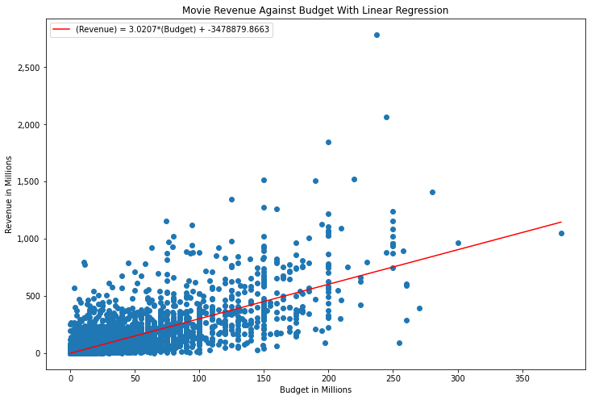

```python
# create linear regression model and fit it
model_lin_reg = sklearn.linear_model.LinearRegression()
model_lin_reg.fit(np.array(df.budget).reshape(-1, 1), np.array(df.revenue))
# print(f"Linear Regression: (Revenue) = {model_lin_reg.coef_[0]:.4f}*(Budget) + {model_lin_reg.intercept_:.4f}")

# create scatter plot of revenue against budget
# plt.figure(figsize=(20, 16))
fig, ax = plt.subplots(figsize=(12, 8))
ax.get_xaxis().set_major_formatter(
    matplotlib.ticker.FuncFormatter(lambda x, p: format(int(x//1000000), ',')))
ax.get_yaxis().set_major_formatter(
    matplotlib.ticker.FuncFormatter(lambda x, p: format(int(x//1000000), ',')))
plt.scatter(df.budget, df.revenue)

# plot linear model_lin_reg on domain inside graph
domain = np.linspace(0, df.budget.max(), 100)
plt.plot(domain, model_lin_reg.predict(domain.reshape(-1, 1)),
         color='red',
         label = f'(Revenue) = {model_lin_reg.coef_[0]:.4f}*(Budget) + {model_lin_reg.intercept_:.4f}'
         )

# label axes
plt.xlabel('Budget in Millions')
plt.ylabel('Revenue in Millions')
plt.title('Movie Revenue Against Budget With Linear Regression')
plt.legend()
plt.show()
```

The model reflects the increasing trend of revenue against budget, as we would expect: a movie with higher budget is a bigger investment, which will tend to yield bigger rewards. There is a simple interpretation to the model coefficient: on average, each dollar increase in the budget (one dollar increase in investment) will yield a 3.02 dollar increase in revenue.

The model seems to fit fairly well. We can quantify how well by calculating the linear regression's $r^2$ value:

```python
model_lin_reg.score(np.array(df.budget).reshape(-1, 1), df.revenue)
```

```
0.5323277516251919
```

This means that over 50% of the variance in the revenue is explained by this linear relationship with the budget. Budget is therefore an extremely important (possibly the most important) factor in determining a movie's revenue.

### Section 3.2: Differences by Genre

Movie genres are strong indicators of target audience, content, and marketability, so it likely has a strong effect on box office success. We draw a violin plot for every genre in our dataset side-by-side and perform a qualitative comparison.

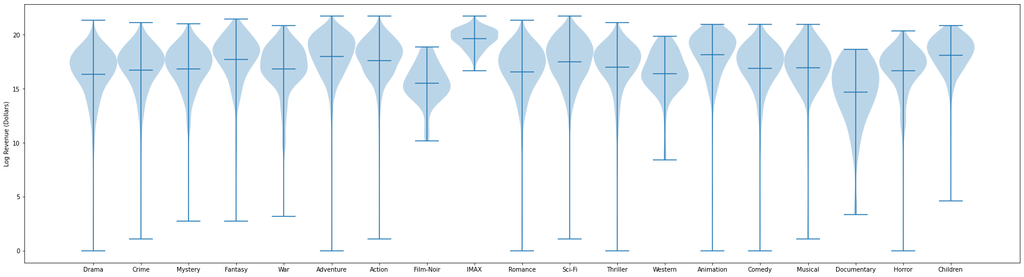

```python
# get list of all genres
genres = list(filter(lambda c: 'genre' in c, df.columns))

# create violinplot
plt.figure(figsize=(30, 8))
ax = plt.subplot(111)
plt.violinplot([np.log(np.asarray(df[df[g]].revenue)) for g in genres], positions=range(len(genres)), widths=1, showmeans=True)
ax.set_xticks(list(range(len(genres))))
ax.set_xticklabels(list(map(lambda g: g[6:], genres))) # set cleaned genre names on x axis
ax.set_ylabel('Log Revenue (Dollars)')
plt.show()
```

```python
for genre in genres:
  print(f"{genre}: {df[genre].sum()}")
```

```
genre_Drama: 2489
genre_Crime: 755
genre_Mystery: 342
genre_Fantasy: 470
genre_War: 243
genre_Adventure: 862
genre_Action: 1351
genre_Film-Noir: 27
genre_IMAX: 150
genre_Romance: 939
genre_Sci-Fi: 599
genre_Thriller: 1377
genre_Western: 94
genre_Animation: 281
genre_Comedy: 1837
genre_Musical: 182
genre_Documentary: 61
genre_Horror: 555
genre_Children: 378
```

We see that IMAX movies perform very well, while documentaries don't. This makes intuitive sense: IMAX movies are shown in theatres and often recieve significant advertising, while documentaries are harder to market for and often target a specific demographic or interest group. Almost all of the distributions have thin tails towards the low-end of revenue, but the region around the mean is fairly symmetric / bulbous. This indicates an approximately lognormal distribution about the means (the y-axis of the graph has a log scale). The majority of "typical" genres (Action, Romance, Sci-Fi) don't seem to have a major effect on revenue distribution; only the "strange" genres do.

We will do the same for production company. Often times, certain companies have a "brand name" where more popular companies will gain a consumer following just because viewers are acquainted with the style of movie that a company creates.

```
['prod_company_Working Title Films', 'prod_company_Canal+', 'prod_company_Touchstone Pictures', 'prod_company_Summit Entertainment', 'prod_company_Village Roadshow Pictures', 'prod_company_Dune Entertainment', 'prod_company_Lionsgate', 'prod_company_Fox Searchlight Pictures', 'prod_company_DreamWork…
[52, 88, 129, 59, 86, 59, 62, 53, 77, 93, 417, 210, 117, 91, 174, 131, 338, 113, 296, 384, 71, 57, 51, 88, 163, 2355]
```

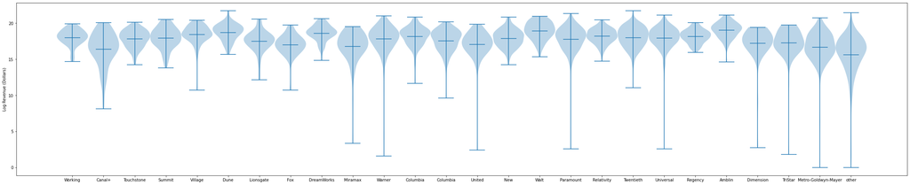

```python
# get list of all companies
companies = list(filter(lambda c: 'prod_company' in c, df.columns))
print(companies)
# create violinplot
plt.figure(figsize=(40, 8))
ax = plt.subplot(111)
print([len(df[df[c]].revenue) for c in companies])
plt.violinplot([np.log(np.asarray(df[df[c]].revenue)) for c in companies], positions=range(len(companies)), widths=1, showmeans=True)
ax.set_xticks(list(range(len(companies))))
ax.set_xticklabels(list(map(lambda g: g[13:].split(" ")[0], companies))) # set cleaned genre names on x axis
ax.set_ylabel('Log Revenue (Dollars)')
plt.show()
```

Surprisingly, there doesn't appear to be much difference between the company and the performance of a movie. They all have relatively the same mean except for the violin plot of "other movies". I think part of the reason we are seeing similar revenues is because we are only displaying companies with more with 50 movies produced. These are old companies with big budgets, so we should expect them to all perform relatively the same. On the contrary, we are not displaying smaller companies with less than 50 movies which likely have lower performance. This is likely why our violin plot for "other" companies (ie the ones with less than 50 movies) do worse on average than the rest of the companies.

### Section 3.3: Distribution of Timing

Movie releases are carefully timed events. Releases often align with certain times of the year (summer blockbusters, holiday season), but also try to not overlap with other major releases which could draw crowds away.

We begin by plotting the distributions of release day-of-the-week.

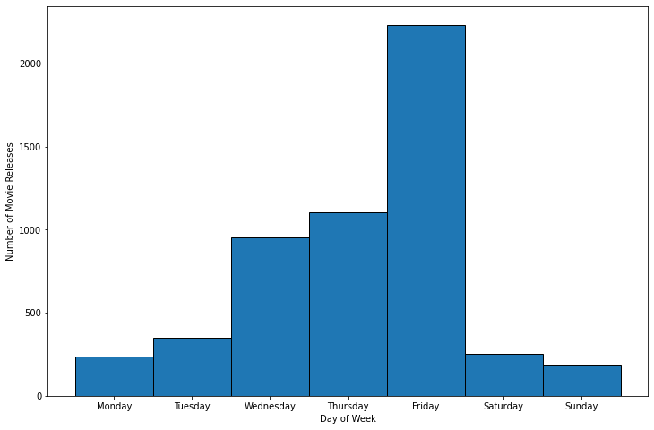

```python
fig, ax = plt.subplots(figsize=(12, 8))
values, bins, bars = ax.hist(df.release_date.dt.day_of_week, edgecolor='black', bins=np.arange(7+1))
ax.set_xticks(np.arange(7)+0.5)
ax.set_xticklabels(['Monday', 'Tuesday', 'Wednesday', 'Thursday', 'Friday', 'Saturday', 'Sunday'])
# ax.bar_label(bars)
ax.set_xlabel('Day of Week')
ax.set_ylabel('Number of Movie Releases')
plt.show()
```

Movies very often release on Fridays, followed the the middle of the week, with few releases over the weekend or start of the week. This makes some sense: peoeple get off work on Friday and can go to see the first viewings, then the opening weekend will take place immediately after. This timing is intuitive and strategic.

We next plot the distribution of release month-of-the-year.

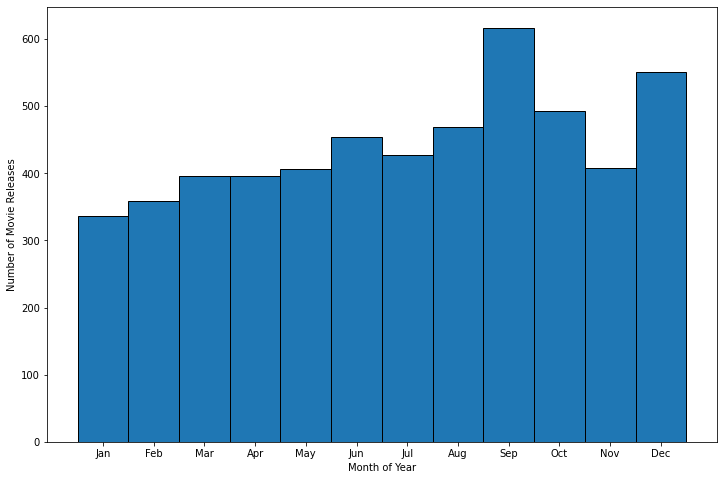

```python
fig, ax = plt.subplots(figsize=(12, 8))
values, bins, bars = ax.hist(df.month, edgecolor='black', bins=np.arange(13)+1)
ax.set_xticks(np.arange(12)+1.5)
ax.set_xticklabels(list(calendar.month_abbr)[1:])
# ax.bar_label(bars)
ax.set_xlabel('Month of Year')
ax.set_ylabel('Number of Movie Releases')
plt.show()
```

The two most popular months are September and December, which align with the end-of-summer and holiday releases. However, these months don't dominate as strongly -- plenty of movies release throughout the year.

Finally, we wish to plot the distribution of movie releases over the calendar year. This is tricky, as the movie releases in the dataset span many years, and it would be impractical to visualize them separately. What we are mainly interested in is whether certain specific days are popular, so preserving day-of-the-week is not a concern. Thus, we take an approximation: for each release date, we transform its (day, month) combination onto the year 2020 (chosen because it is a leap year, so all days will be accounted for). We plot this distribution below.

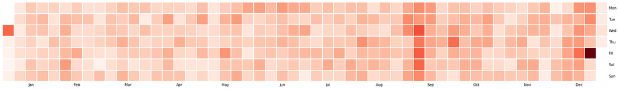

```python
plt.figure(figsize=(30, 20))
calmap.yearplot(pd.Series(1, index=df.release_date.map(lambda rd: pd.to_datetime(f"{rd.month}-{rd.day}-2020"))))
plt.show()
```

We see that New years, Christmas and its surrounding days, as well as the first week of September are all common release dates. This aligns with the previous analysis that released summer-blockbuster and holiday releases to be popular. For the rest of the calendar dates, releases seem to be mostly uniformly distributed, or at least without a significant pattern.

### Section 3.4: Popularity of Genres over Time

We will now plot the revenues of each genre for each clump of 5 years. We want to determine if certain genres so in and out of fashion. Perhaps in one decade, one genre was extremely popular and in another decade, another genre was more popular.

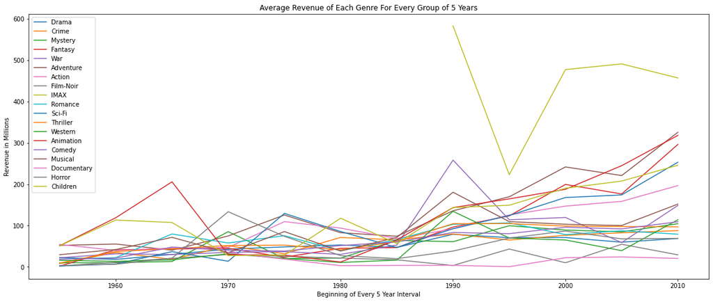

```python
fig, ax = plt.subplots(figsize=(20, 8))
df_copy = df.copy()
df_copy['group_of_5'] = df['year'].apply(lambda elm: elm - (elm % 5))
for column in df.columns:
  if column[0:6] == 'genre_':
    # if this column is for a genre
    only_curr_genre_info = df_copy[df[column]]
    years_of_5 = []
    avg_per_5_years = []
    for year, df_corresponding in only_curr_genre_info.groupby('group_of_5'):
      if year > 1950 and year < 2015:
        years_of_5.append(year)
        avg_per_5_years.append(df_corresponding['revenue'].mean())
    ax.plot(years_of_5, avg_per_5_years, label = column[6:])


ax.legend()
ax.get_yaxis().set_major_formatter(
    matplotlib.ticker.FuncFormatter(lambda x, p: format(int(x//1000000), ',')))
ax.set_ylabel('Revenue in Millions')
ax.set_xlabel('Beginning of Every 5 Year Interval')
ax.set_title('Average Revenue of Each Genre For Every Group of 5 Years')
```

Notice that almost every genre has an upward trend. We believe this phenomena is because inflation causes prices to increase which also increases the revenue of movies.

## Section 4: Models and Regression

Our hopes is to create effective models to predict the performance of upcoming movies and in the box office. To do so, we will test various regression techniques. Currently, the only predict method we have created is a linear regression between budget and revenue. We will proceed with more advanced machine learning methods.

### Section 4.1: Paritioning Data

We first show which columns are left in the dataset

```python
for column in df.columns:
  print(column)
```

```
adult
budget
original_language
original_title
overview
release_date
revenue
runtime
status
tagline
title
year
month
day
genre_Drama
genre_Crime
genre_Mystery
genre_Fantasy
genre_War
genre_Adventure
genre_Action
genre_Film-Noir
genre_IMAX
genre_Romance
genre_Sci-Fi
genre_Thriller
genre_Western
genre_Animation
genre_Comedy
genre_Musical
genre_Documentary
genre_Horror
genre_Children
spoken_lang_pt
spoken_lang_cn
spoken_lang_ja
spoken_lang_ar
spoken_lang_es
spoken_lang_it
spoken_lang_zh
```

[output cut: 30 more lines]

```
prod_company_Columbia Pictures
prod_company_Columbia Pictures Corporation
prod_company_United Artists
prod_company_New Line Cinema
prod_company_Walt Disney Pictures
prod_company_Paramount Pictures
prod_company_Relativity Media
prod_company_Twentieth Century Fox Film Corporation
prod_company_Universal Pictures
prod_company_Regency Enterprises
prod_company_Amblin Entertainment
prod_company_Dimension Films
prod_company_TriStar Pictures
prod_company_Metro-Goldwyn-Mayer (MGM)
prod_company_other
```

We will drop the columns:

- original_language (already one hot encoded)
- original_title
- overview
- release_date (which is broken up into year, month, and day columns)
- status
- tagline
- title

```python
df_reg = df.drop(columns = ['original_language', 'original_title', 'overview', 'release_date', 'status', 'tagline', 'title'])
```

We will convert all bool columns to int64 because SKLearn uses int columns for bool values

```python
for column in df_reg.columns:
  if df_reg.dtypes[column] == bool:
    df_reg[column] = df_reg[column].astype(int)

df_reg.dropna(inplace = True)
df_reg = df_reg.astype(float)
```

```python
df_reg.info()
```

```
<class 'pandas.core.frame.DataFrame'>
Int64Index: 5313 entries, 0 to 5313
Data columns (total 78 columns):
 #   Column                                               Non-Null Count  Dtype
---  ------                                               --------------  -----
 0   adult                                                5313 non-null   float64
 1   budget                                               5313 non-null   float64
 2   revenue                                              5313 non-null   float64
 3   runtime                                              5313 non-null   float64
 4   year                                                 5313 non-null   float64
 5   month                                                5313 non-null   float64
 6   day                                                  5313 non-null   float64
 7   genre_Drama                                          5313 non-null   float64
 8   genre_Crime                                          5313 non-null   float64
 9   genre_Mystery                                        5313 non-null   float64
```

[output cut: 70 more lines]

We will split this into new dataframe into a training dataset and a testing dataset

```python
from sklearn.model_selection import train_test_split
df_train, df_test = train_test_split(df_reg, random_state = 1345)
```

### Section 4.1: k-Nearest Regression

The first type of regression technicque we will try is k-nearest neighbors:

```python
from sklearn.neighbors import KNeighborsRegressor

model_knn = KNeighborsRegressor()
# model_knn.fit(df_train.drop(columns = ['revenue', 'revenue_adj', 'budget_adj'], axis = 1), df_train['revenue'])
model_knn.fit(df_train.drop(columns = ['revenue'], axis = 1), df_train['revenue'])
```

```
KNeighborsRegressor()
```

```python
# model_knn.score(df_test.drop(columns = ['revenue', 'revenue_adj', 'budget_adj'], axis = 1), df_test['revenue'])
model_knn.score(df_test.drop(columns = ['revenue'], axis = 1), df_test['revenue'])
```

```
0.5249263540361953
```

Our low score could be attributed to the fact that our budget is unnormalized and so when comparing distance, budget dominates any comparison because it is orders of magnitude greater than anything else.

### Section 4.2: Random Forest

```python
from sklearn.ensemble import RandomForestRegressor

model_rand = RandomForestRegressor(random_state = 134509)
model_rand.fit(df_train.drop(columns = ['revenue'], axis = 1), df_train['revenue'])
```

```
RandomForestRegressor(random_state=134509)
```

```python
model_rand.score(df_test.drop(columns = ['revenue'], axis = 1), df_test['revenue'])
```

```
0.6139465144093548
```

We will also drop language because the vast majority of movies are in English anyways. Similarly, we will drop the columns for production country because most of them are in the United States.

```python
df_reg = df_reg[
    [
      # 'prod_company_other',
      'adult',
      'budget',
      'revenue',
      'runtime',
      'year',
      'month',
      'day',
      'genre_Mystery',
      'genre_Adventure',
      'genre_War',
      'genre_Animation',
      'genre_Musical',
      'genre_IMAX',
      'genre_Western',
      'genre_Sci-Fi',
      'genre_Crime',
      'genre_Romance',
      'genre_Children',
      'genre_Documentary',
      'genre_Action',
      'genre_Drama',
      'genre_Fantasy',
      'genre_Film-Noir',
      'genre_Comedy',
      'genre_Thriller',
      'genre_Horror',
  ]
]
```

```python
df_train, df_test = train_test_split(df_reg, random_state = 1345)
```

### Section 4.3: KNN (with less categories)

```python
from sklearn.neighbors import KNeighborsRegressor

model_knn = KNeighborsRegressor()
model_knn.fit(df_train.drop(columns = ['revenue'], axis = 1), df_train['revenue'])
```

```
KNeighborsRegressor()
```

```python
model_knn.score(df_test.drop(columns = ['revenue'], axis = 1), df_test['revenue'])
```

```
0.5247756097620906
```

Note that the KNN regression does almost the exact same even without the added categories.

### Section 4.4 Random Forest (with less categories)

```python
model_rand = RandomForestRegressor(random_state = 123)
model_rand.fit(df_train.drop(columns = ['revenue'], axis = 1), df_train['revenue'])
```

```
RandomForestRegressor(random_state=123)
```

```python
model_rand.score(df_test.drop(columns = ['revenue'], axis = 1), df_test['revenue'])
```

```
0.6102218497675025
```

Similarly, the random forest regressor performs about as good without the added one hot encoded categories.

### Section 4.5 Neural Network (with less categories)

Finally, we will try running using a neural network:

```python
df_train.head()
```

|  | adult | budget | revenue | runtime | year | month | day | genre_Mystery | genre_Adventure | genre_War | ... | genre_Romance | genre_Children | genre_Documentary | genre_Action | genre_Drama | genre_Fantasy | genre_Film-Noir | genre_Comedy | genre_Thriller | genre_Horror |
| --- | --- | --- | --- | --- | --- | --- | --- | --- | --- | --- | --- | --- | --- | --- | --- | --- | --- | --- | --- | --- | --- |
| 2209 | 1.0 | 15000000.0 | 15121165.0 | 115.0 | 2003.0 | 9.0 | 1.0 | 0.0 | 0.0 | 0.0 | ... | 0.0 | 0.0 | 0.0 | 0.0 | 1.0 | 0.0 | 0.0 | 0.0 | 0.0 | 0.0 |
| 1632 | 1.0 | 48000000.0 | 85498534.0 | 112.0 | 2001.0 | 7.0 | 30.0 | 0.0 | 0.0 | 0.0 | ... | 0.0 | 0.0 | 0.0 | 0.0 | 0.0 | 0.0 | 0.0 | 1.0 | 0.0 | 0.0 |
| 3444 | 1.0 | 2900000.0 | 296557.0 | 90.0 | 2009.0 | 10.0 | 16.0 | 0.0 | 0.0 | 0.0 | ... | 0.0 | 0.0 | 0.0 | 1.0 | 0.0 | 0.0 | 0.0 | 1.0 | 0.0 | 0.0 |
| 3903 | 1.0 | 20000000.0 | 177243185.0 | 115.0 | 2011.0 | 9.0 | 9.0 | 0.0 | 0.0 | 0.0 | ... | 0.0 | 0.0 | 0.0 | 0.0 | 1.0 | 0.0 | 0.0 | 1.0 | 0.0 | 0.0 |
| 3648 | 1.0 | 18000000.0 | 5602431.0 | 80.0 | 2010.0 | 2.0 | 16.0 | 0.0 | 0.0 | 0.0 | ... | 0.0 | 0.0 | 0.0 | 0.0 | 0.0 | 0.0 | 0.0 | 0.0 | 0.0 | 0.0 |

5 rows × 26 columns

```python
import torch
from torch.utils.data import Dataset
torch.set_default_dtype(torch.float64)
torch.set_grad_enabled(True)
class RegressionDataset(Dataset):
  def __init__(self, data):
        data = data.reset_index(drop = True)
        self.targets = torch.from_numpy(np.asarray(data['revenue'].values, dtype = np.float64))
        self.input_data = torch.from_numpy(np.asarray(data.drop('revenue', axis = 1).values, dtype = np.float64))

        # print(len(data.drop('revenue', axis = 1).columns))
  def __getitem__(self, index):
      return (self.input_data[index], self.targets[index])

  def __len__ (self):
      return len(self.input_data)


from torch.utils.data import DataLoader

dataloader_train = DataLoader(dataset = RegressionDataset(df_train))
dataloader_test = DataLoader(dataset = RegressionDataset(df_test))
```

```python
import torch.nn as nn
from torch.nn.functional import relu, logsigmoid


class RegressionNetwork(nn.Module):

    def __init__(self):
        super(RegressionNetwork, self).__init__()
        self.fc1 = nn.Linear(25, 20)
        self.fc2 = nn.Linear(20, 15)
        self.fc3 = nn.Linear(15, 10)
        self.fc4 = nn.Linear(10, 5)
        self.fc5 = nn.Linear(5, 1)

    def forward(self, x):
        x = relu(self.fc1(x))
        x = relu(self.fc2(x))
        x = relu(self.fc3(x))
        x = relu(self.fc4(x))
        x = relu(self.fc5(x))
        # print('output:', x)
        return x
```

```python
import torch.optim as optim
from torch.autograd import Variable


import random
random.seed(0)
np.random.seed(0)
torch.manual_seed(0)


net = RegressionNetwork()
print(net)
criterion = nn.MSELoss()
optimizer = optim.Adam(net.parameters(), lr=0.02)

epochs = 20

for _ in range(epochs): # repeat for however number of epochs
  train_loss_epoch = 0
  for input, target in dataloader_train:
    input = Variable(input, requires_grad = False)
    optimizer.zero_grad()
    # print(input)
    output = net(input)
    # print(loss)
    loss = criterion(output, target)
    loss.backward()
    # print(loss)
    optimizer.step()
    train_loss_epoch += loss.item()

  test_loss_epoch = 0
  for input, target in dataloader_test:
    input = Variable(input, requires_grad = False)
    optimizer.zero_grad()
    # print(input)
    output = net(input)
    # print(loss)
    loss = criterion(output, target)
    loss.backward()
    # print(loss)
    optimizer.step()
    test_loss_epoch += loss.item()
  print('epoch ' + str(_+1) + ':')
  print('training loss:', train_loss_epoch / len(dataloader_train))
  print('test loss:', test_loss_epoch / len(dataloader_test))
```

```
RegressionNetwork(
  (fc1): Linear(in_features=25, out_features=20, bias=True)
  (fc2): Linear(in_features=20, out_features=15, bias=True)
  (fc3): Linear(in_features=15, out_features=10, bias=True)
  (fc4): Linear(in_features=10, out_features=5, bias=True)
  (fc5): Linear(in_features=5, out_features=1, bias=True)
)
```

```
epoch 1:
training loss: 1.6287150425960204e+16
test loss: 2.134264631343772e+16
epoch 2:
training loss: 1.4202975180578094e+16
test loss: 1.9829707256540804e+16
epoch 3:
training loss: 1.3556628792678528e+16
test loss: 1.9626096302611344e+16
epoch 4:
training loss: 1.3631283960391148e+16
test loss: 1.951115720757655e+16
epoch 5:
training loss: 1.3387224360040902e+16
test loss: 1.9309311479191004e+16
epoch 6:
training loss: 1.3671866919015056e+16
test loss: 1.9820744756380756e+16
epoch 7:
training loss: 1.375903460655351e+16
test loss: 1.9671002244271292e+16
epoch 8:
training loss: 1.352673210299426e+16
test loss: 1.9609715834054764e+16
epoch 9:
training loss: 1.3465950115552354e+16
test loss: 1.9418478367241744e+16
epoch 10:
training loss: 1.3545441034647758e+16
test loss: 1.958371446939015e+16
epoch 11:
training loss: 1.3579661739232038e+16
test loss: 1.9456858193281716e+16
epoch 12:
training loss: 1.3460687357286054e+16
test loss: 1.951617779124316e+16
epoch 13:
training loss: 1.3430898200060946e+16
test loss: 1.9479469499499972e+16
epoch 14:
training loss: 1.338657954439094e+16
test loss: 1.9352739125721892e+16
epoch 15:
training loss: 1.3456595869369102e+16
test loss: 1.916632633600261e+16
epoch 16:
training loss: 1.3199265783619302e+16
test loss: 1.915942779190091e+16
epoch 17:
training loss: 1.3248153949419538e+16
test loss: 1.9218150261006788e+16
epoch 18:
training loss: 1.320012895880065e+16
test loss: 1.9154689488233296e+16
epoch 19:
training loss: 1.3252898518975456e+16
test loss: 1.915403523800211e+16
epoch 20:
training loss: 1.3194131702625104e+16
test loss: 1.9152894427502896e+16
```

We will now evaluate our neural nerwork by finding its R^2 value.

```python
from sklearn.metrics import r2_score

tensor_test = torch.from_numpy(np.asarray(df_test.drop('revenue', axis = 1).values, dtype = np.float64))
# print(tensor_test.shape)

model_outputs_test = net(tensor_test)
r2_score(df_test['revenue'], model_outputs_test.detach())
```

```
0.5339704750510825
```

Interestingly our Neural Network doesn't do as well as a random forest. We believe part of the reason this is happening is because there isn't much data to train the neural network on. There is only 5000 total entries and often neural networks make more than that to train. Additionally, our neural network is very small, so there may not be enough power in our network to understand more advanced processes.

### Section 4.6: Summary of models

It appears that of the models trained, random forest was the most effective regression technique. It is the only model to predict at a R^2 level above 0.6. This makes sense because our data is full of categories, and often decision trees are the most effective at dealing with a large amount of categories.

Additionally, it appears that the language and production company information for each movies largely seems irrelevant. When we removed these columns, we still ended out with roughly the same effectiveness in our regressions, as evidenced by our R^2 values.

## Section 5: Upcoming Movie Predictions

- Avatar 2: The Way of Water
- Aquaman 2: The Lost Kingdom
- Black Panther 2: Wakanda Forever
- Black Adam
- Babylon

Information on these movies was acquired from the following website: https://www.thefilmik.com/upcoming-big-budget-hollywood-movies-2022/

```python
upcomingMovieData = {
    'name':['Avatar 2', 'Aquaman 2', 'Black Panther 2', 'Black Adam', 'Babylon'],
    'adult':[False, False, False, False, True],
    'budget' : [375 * 10**6, 235 * 10**6, 250 * 10**6, 192.5 * 10**6, 109 * 10**6],
    'runtime' : [192, 143, 161, 124, 189],
    'year': [2022, 2023, 2022, 2022, 2022],
    'month' : [12, 12, 11, 11, 12],
    'day': [16, 25, 11, 21, 25],
    'genre_Mystery': [False, False, False, False, False],
    'genre_Adventure': [False, True, False, False, False],
    'genre_War': [True, False, True, False, False],
    'genre_Animation': [False, False, False, False, False],
    'genre_Musical': [False, False, False, False, False],
    'genre_IMAX': [True, True, True, False, False],
    'genre_Western': [False, False, False, False, False],
    'genre_Sci-Fi': [True, False, True, False, False],
    'genre_Crime': [False, False, False, False, False],
    'genre_Romance': [False, False, False, False, True],
    'genre_Children': [False, False, False, False, False],
    'genre_Documentary': [False, False, False, False, False],
    'genre_Action': [True, True, True, True, False],
    'genre_Drama': [True, False, False, False, True],
    'genre_Fantasy': [True, True, True, True, False],
    'genre_Film-Noir': [False, False, False, False, False],
    'genre_Comedy': [False, False, False, False, False],
    'genre_Thriller': [False, False, False, False, False],
    'genre_Horror': [False, False, False, False, False],
}


# make dataframe from map
upcoming_movie_df = pd.DataFrame(upcomingMovieData)
upcoming_movie_df.head()

# remove names from the df
names = upcoming_movie_df['name']
predictors = upcoming_movie_df.drop('name', axis = 1)
predictors = predictors.astype(np.float64)
```

We will have our previously trained models predict movie performance based on movie parameters.

```python
import warnings
warnings.filterwarnings("ignore")

predictions = []
for i in range(5):
  predictor_row = np.array(predictors.iloc[i])
  predictions.append(
      {
       'Neural Network': net(torch.Tensor(predictor_row)).detach().item(),
       'K Nearest Neighbors' : model_knn.predict(predictor_row.reshape(1, -1))[0],
       'Random Forest' : model_rand.predict(predictor_row.reshape(1, -1))[0],
       'Linear Regression \n(between budget and revenue)' : model_lin_reg.predict(np.array([[predictor_row[1]]]))[0]
      }
  )


# predictions
```

Graph the regression output values for each upcoming movie:

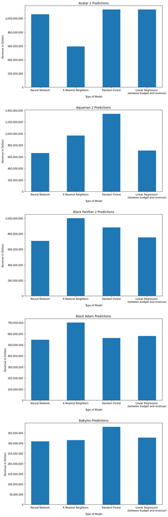

```python
# make 5 subplots for the 5 bins
fig, axs = plt.subplots(5)
fig.set_figwidth(10)
fig.set_figheight(30)
fig.tight_layout(pad=7.0) # set the distance between successive plots

for i in range(5):
  prediction_dict = predictions[i]
  labels = []
  values = []
  for key,val in prediction_dict.items():
    if key != 'name':
      labels.append(key)
      values.append(val)


  # create the bar graph
  axs[i].bar(labels, values, width = 0.5)
  axs[i].set_title(names.iloc[i] + ' Predictions')
  axs[i].set_ylabel('Revenue in Dollars')
  axs[i].set_xlabel('Type of Model')
  axs[i].get_yaxis().set_major_formatter(
    matplotlib.ticker.FuncFormatter(lambda x, p: format(int(x), ','))) # add commas to the y axis integer values
```

We will graph the expected revenues of all the movies and all the models together:

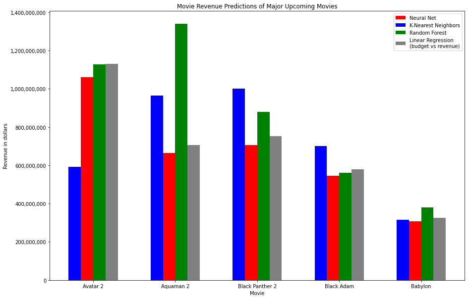

```python
fig, ax = plt.subplots(1)

fig.set_figwidth(15)
fig.set_figheight(10)

ax.get_yaxis().set_major_formatter(
  matplotlib.ticker.FuncFormatter(lambda x, p: format(int(x), ','))) # add commas to the y axis integer values
ax.set_ylabel('Revenue in dollars')
ax.set_xlabel('Movie')

X_axis = np.arange(len(names))


# bars for neural network
labels = [names.iloc[i] for i in range(len(names))]
values = []
for i in range(len(names)):
  predictor_row = np.array(predictors.iloc[i])
  values.append(net(torch.Tensor(predictor_row)).detach().item())
ax.bar(X_axis-0.05*1.5, values, color = 'red', width = 0.1*1.5, label = 'Neural Net')

# bars for KNN
values = []
for i in range(len(names)):
  predictor_row = np.array(predictors.iloc[i])
  values.append(model_knn.predict(predictor_row.reshape(1, -1))[0])
ax.bar(X_axis-0.15*1.5, values, color = 'blue', width = 0.1*1.5, label = 'K-Nearest Neighbors')

# bars for Random Forest
values = []
for i in range(len(names)):
  predictor_row = np.array(predictors.iloc[i])
  values.append(model_rand.predict(predictor_row.reshape(1, -1))[0])
ax.bar(X_axis+0.05*1.5, values, color = 'green', width = 0.1*1.5, label = 'Random Forest')

# bars for regression
values = []
for i in range(len(names)):
  predictor_row = np.array(predictors.iloc[i])
  values.append(model_lin_reg.predict(np.array([[predictor_row[1]]]))[0])
ax.bar(X_axis+0.15*1.5, values, color = 'grey', width = 0.1*1.5, label = 'Linear Regression\n(budget vs revenue)')

# make the x axis names of the models
plt.xticks(X_axis, labels)
plt.legend()
plt.title("Movie Revenue Predictions of Major Upcoming Movies")
```

Interestingly, the neural network and the linear regression predict almost the same consistently whereas the random forest and knn seem to predict very independently from the other regression techniques.

From what is appears from the various regressions, we believe that Avatar 2 and Aquaman 2 are going to raise the most revenue. We have very high confidence that Babylon is going to perform the worst in the box office because each regression's lowest prediction is for Babylon.

## Section 6. Conclusion

In this walkthrough, we collected, processed, combined, and encoded complex datasets regarding past movies and their performances. We explored our dataset through several avenues, including budget, genre, and release time, to heuristically determine what factors influence a movie's box office; while these factors were important, features such as production company and language were not. We then utilized several machine-learning regression models to try to predict box office success given movie characteristics, and achieved moderate success. Finally, we used our predictors to analyze upcoming movies.

Our list of factors is not complete -- there are certainly more characteristics of movies that serve as important factors in a movie's performance; these could include star actors or advertising costs. A larger dataset that includes these features could allow us to achieve better predictive performance, which could be the subject of further analysis. We hope you have enjoyed reading this tutorial and have learned data science techniques that will be useful in your future exploration!